# Assignment 1: Linear model selection

Thomas Vanpoucke, Boris Shilov

```r
library(glmnet)
library(pls)
library(leaps)
set.seed(10)
prostate = get(load("prostate2.Rdata"))
prostate$svi = as.factor(prostate$svi)
attach(prostate)
options(digits=3)
```

# Variable comparison and evaluation

There are 97 data points, seven predictor variables and one response variable, Cscore. There is one binary variable, svi. Looking at the scatterplots below, there seem to be a few strong positive correlations present, such as those between Cscore and lpsa as well as lcavol and lpsa.

When looking at the first data points, we noticed that there were some recurring numbers, specifically within the lbph and lcp predictor variables.

```r
head(prostate)
```

|  | Cscore | lcavol | lweight | age | lbph | svi | lcp | lpsa |
| --- | --- | --- | --- | --- | --- | --- | --- | --- |
| 1 | 10.48 | -0.580 | 2.77 | 50 | -1.39 | 0 | -1.39 | -0.431 |
| 2 | 1.08 | -0.994 | 3.32 | 58 | -1.39 | 0 | -1.39 | -0.163 |
| 3 | 16.10 | -0.511 | 2.69 | 74 | -1.39 | 0 | -1.39 | -0.163 |
| 4 | -16.39 | -1.204 | 3.28 | 58 | -1.39 | 0 | -1.39 | -0.163 |
| 5 | 21.08 | 0.751 | 3.43 | 62 | -1.39 | 0 | -1.39 | 0.372 |
| 6 | 18.86 | -1.050 | 3.23 | 50 | -1.39 | 0 | -1.39 | 0.765 |

```r
summary(prostate)
```

```
     Cscore        lcavol         lweight          age            lbph       svi
 Min.   :-19   Min.   :-1.35   Min.   :2.37   Min.   :41.0   Min.   :-1.39   0:76
 1st Qu.:  9   1st Qu.: 0.51   1st Qu.:3.38   1st Qu.:60.0   1st Qu.:-1.39   1:21
 Median : 21   Median : 1.45   Median :3.62   Median :65.0   Median : 0.30
 Mean   : 36   Mean   : 1.35   Mean   :3.65   Mean   :63.9   Mean   : 0.10
 3rd Qu.: 49   3rd Qu.: 2.13   3rd Qu.:3.88   3rd Qu.:68.0   3rd Qu.: 1.56
 Max.   :373   Max.   : 3.82   Max.   :6.11   Max.   :79.0   Max.   : 2.33
      lcp              lpsa
 Min.   :-1.386   Min.   :-0.43
 1st Qu.:-1.386   1st Qu.: 1.73
 Median :-0.799   Median : 2.59
 Mean   :-0.179   Mean   : 2.48
 3rd Qu.: 1.179   3rd Qu.: 3.06
 Max.   : 2.904   Max.   : 5.58
```

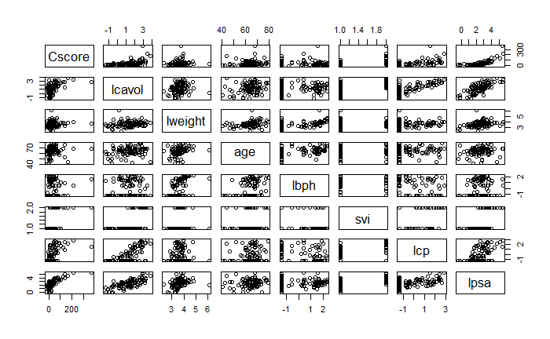

```r
plot(prostate)
```

# Forward stepwise selection

We implemented algorithm 6.2 for forward stepwise selection. To choose which parameter to add in one round of forward stepwise selection, we used the model with the highest $R^2$ value, as per the algorithm. To select the single best model, we used BIC. The entire function code can be found in the source file for this document.

```
Call:
lm(formula = paste(data_vars[1], "~", paste(predictor_list, collapse = "+",
    "+", paste(data_vars[i]))), data = data)

Coefficients:
(Intercept)         lpsa         svi1
      -37.0         26.9         29.8


Call:
lm(formula = paste(data_vars[1], "~", paste(predictor_list, collapse = "+",
    "+", paste(data_vars[i]))), data = data)

Residuals:
   Min     1Q Median     3Q    Max
-60.83 -19.18  -4.72  13.51 232.87

Coefficients:
            Estimate Std. Error t value Pr(>|t|)
(Intercept)   -36.98       9.08   -4.07  9.7e-05 ***
lpsa           26.90       3.80    7.08  2.6e-10 ***
svi1           29.81      10.60    2.81    0.006 **
---
Signif. codes:  0 ‘***’ 0.001 ‘**’ 0.01 ‘*’ 0.05 ‘.’ 0.1 ‘ ’ 1

Residual standard error: 35.4 on 94 degrees of freedom
Multiple R-squared:  0.558, Adjusted R-squared:  0.549
F-statistic: 59.3 on 2 and 94 DF,  p-value: <2e-16
```

Thus, the model returned by our algorithm as the best was one with only two predictor variables, lpsa and svi.
$$Cscore = -36.977 + 26.903 \times lpsa + 29.81 \times svi1$$

# Lasso

To do a cross-validated lasso and ridge, we first split up the dataset into two pieces, a training and a test dataset. We made a model, based on the training data, that was crossvalidated within this training data. The test dataset was then used to check the mean squared test error for the best lambda (which is the lowest mean squared training error). To finish off, we used the entire dataset and the best lambda value to construct our lasso model.

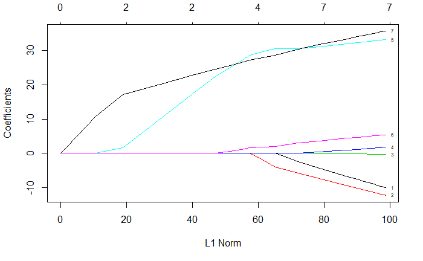

```r
x = model.matrix(Cscore~.,prostate)[,-1]
y = prostate$Cscore
train=sample(1:nrow(x),nrow(x)/2)
test=(-train)
y.test=y[test]
grid=10^seq(10,-2,length=100)
lasso.model=glmnet(x[train,],y[train],alpha=1,lambda=grid, thresh = 1e-12)
plot(lasso.model, label = TRUE)
```

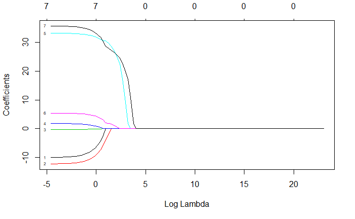

```r
plot(lasso.model,xvar="lambda",label=TRUE)
```

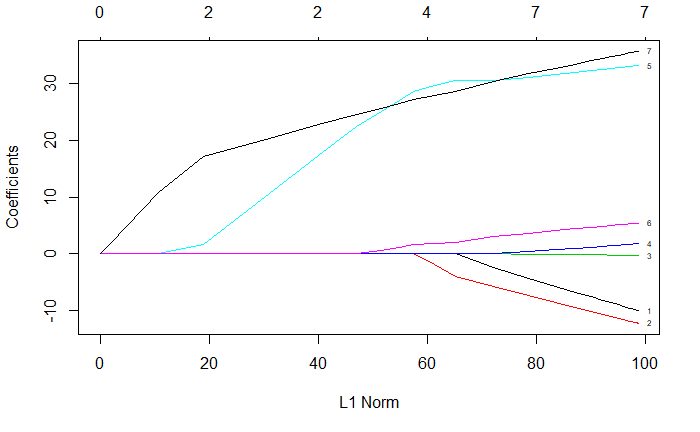

```r
lasso.model=glmnet(x[train,],y[train],alpha=1,lambda=grid, thresh = 1e-12)
OLS.model=glmnet(x[train,],y[train],alpha=1,lambda=0, thresh = 1e-12)
plot(lasso.model, label = TRUE)
```

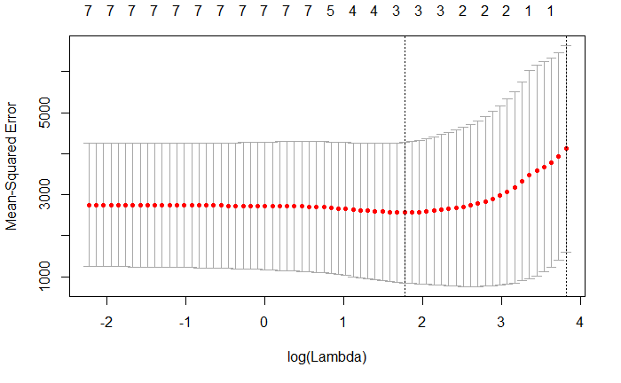

```r
cv.lasso.out=cv.glmnet(x[train,],y[train],alpha=1)
plot(cv.lasso.out)
```

```r
bestlambda.lasso=cv.lasso.out$lambda.min
out=glmnet(x,y,alpha=1,lambda=grid)
lasso.pred = predict(lasso.model,s=bestlambda.lasso,newx=x[test,])
lasso.mean = mean((lasso.pred-y.test)^2)
lasso.coef = predict(out,type="coefficients",s=bestlambda.lasso)[1:8,]
OLS.pred = predict(OLS.model, s=0, newx=x[test,])
OLS.mean = mean((OLS.pred-y.test)^2)
OLS.coef = predict(out, type="coefficients", s=0)[1:8,]
lasso.mean
```

```
[1] 664
```

```r
OLS.mean
```

```
[1] 736
```

```r
lasso.coef
```

```
(Intercept)      lcavol     lweight         age        lbph        svi1         lcp        lpsa
     -23.09        0.00        0.00        0.00        0.00       15.47        2.92       22.76
```

```r
OLS.coef
```

```
(Intercept)      lcavol     lweight         age        lbph        svi1         lcp        lpsa
     -4.705     -10.071     -11.895       0.201      -0.526      18.435       7.790      33.289
```

We can clearly see that Lasso zeroes out a large number of our variables, which is a massive reduction of complexity. Two of the variables agree with our previous best forward selection. Thus Lasso is clearly superior to ordinary least squares in this instance. The resulting Lasso model becomes:
$$Cscore = -23.089 + 15.467 \times svi1 + 2.923 \times lcp + 22.763 \times lpsa$$

# Ridge

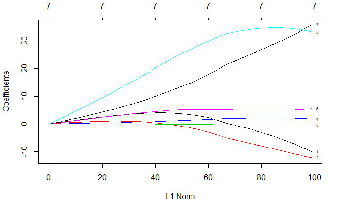

```r
grid=10^seq(10,-2,length=100)
ridge.model=glmnet(x[train,],y[train],alpha=0,lambda=grid, thresh = 1e-12)
OLS.model.ridge=glmnet(x[train,],y[train],alpha=0,lambda=0, thresh = 1e-12)
plot(ridge.model, label = TRUE)
```

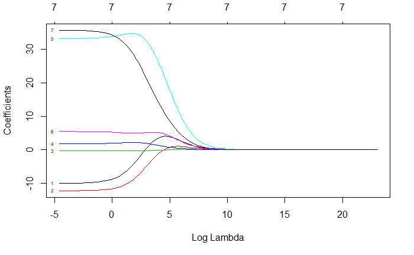

```r
plot(ridge.model,xvar="lambda",label=TRUE)
```

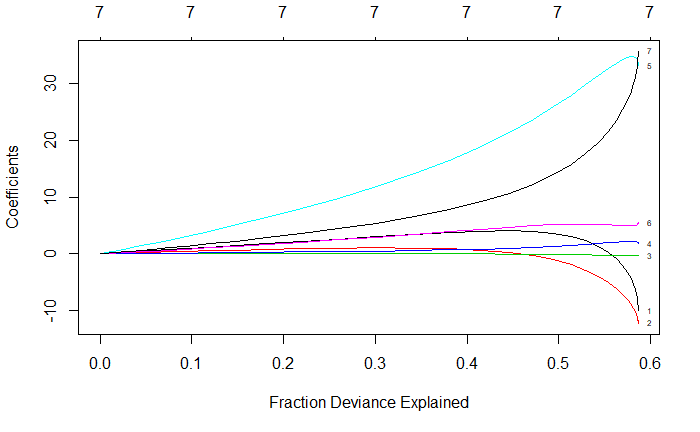

```r
plot(ridge.model,xvar="dev",label=TRUE)
```

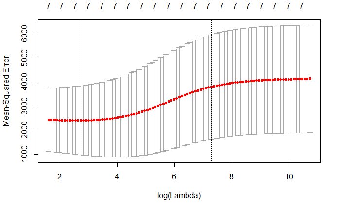

```r
cv.ridge.out=cv.glmnet(x[train,],y[train],alpha=0)
plot(cv.ridge.out)
```

```r
bestlambda.ridge=cv.ridge.out$lambda.min
```

Lowest mean squared error here corresponds to lowest cross validation error. We can conclude that the best $\lambda$ value equals 13.872.

```r
bestlambda.ridge=cv.ridge.out$lambda.min
out.ridge=glmnet(x,y,alpha=1,lambda=grid)
ridge.pred = predict(ridge.model,s=bestlambda.ridge,newx=x[test,])
ridge.mean = mean((ridge.pred-y.test)^2)
ridge.coef = predict(out.ridge,type="coefficients",s=bestlambda.ridge)[1:8,]
OLS.pred.ridge = predict(OLS.model.ridge, s=0, newx=x[test,])
OLS.mean.ridge = mean((OLS.pred.ridge-y.test)^2)
OLS.coef.ridge = predict(out.ridge, type="coefficients", s=0)[1:8,]
ridge.mean
```

```
[1] 675
```

```r
OLS.mean.ridge
```

```
[1] 736
```

```r
ridge.coef
```

```
(Intercept)      lcavol     lweight         age        lbph        svi1         lcp        lpsa
     -12.65        0.00        0.00        0.00        0.00        7.56        0.42       19.06
```

```r
OLS.coef
```

```
(Intercept)      lcavol     lweight         age        lbph        svi1         lcp        lpsa
     -4.705     -10.071     -11.895       0.201      -0.526      18.435       7.790      33.289
```

# Principal Component Regression

## How many principal components would you select for yout PCR model?

```r
set.seed(10)
pcr_model=pcr(Cscore~.,data=prostate,scale=TRUE,
        validation="CV")
summary(pcr_model)
```

```
Data:   X dimension: 97 7
    Y dimension: 97 1
Fit method: svdpc
Number of components considered: 7

VALIDATION: RMSEP
Cross-validated using 10 random segments.
       (Intercept)  1 comps  2 comps  3 comps  4 comps  5 comps  6 comps  7 comps
CV           52.99    40.71    40.06    39.94    39.85    40.56    39.85    37.47
adjCV        52.99    40.61    39.95    39.83    39.71    40.43    39.66    37.26

TRAINING: % variance explained
        1 comps  2 comps  3 comps  4 comps  5 comps  6 comps  7 comps
X         43.44    66.95    77.62    85.37    92.39    97.42   100.00
Cscore    44.91    46.93    47.77    48.25    48.28    52.84    59.22
```

```r
explvar(pcr_model)
```

```
Comp 1 Comp 2 Comp 3 Comp 4 Comp 5 Comp 6 Comp 7
 43.44  23.51  10.67   7.75   7.02   5.03   2.58
```

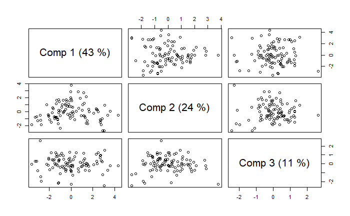

```r
plot(pcr_model, plottype = "scores", comps = 1:3)
```

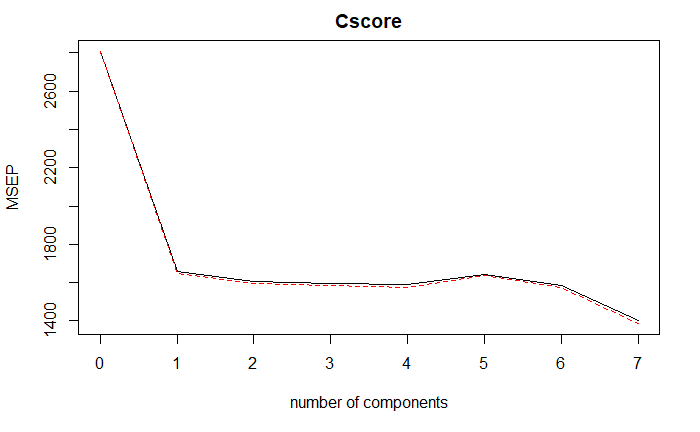

```r
validationplot(pcr_model,val.type="MSEP")
```

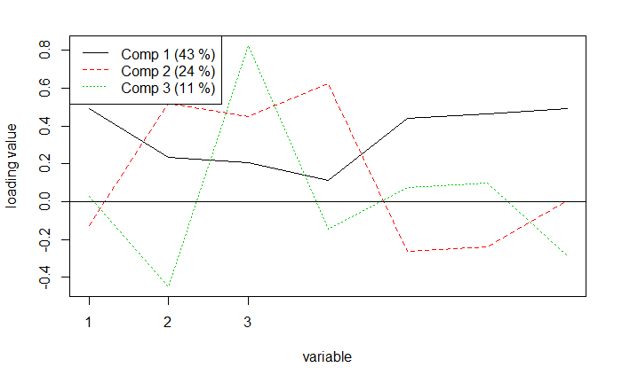

```r
plot(pcr_model, "loadings", comps = 1:3, legendpos = "topleft",labels = 1:3)
abline(h = 0)
```

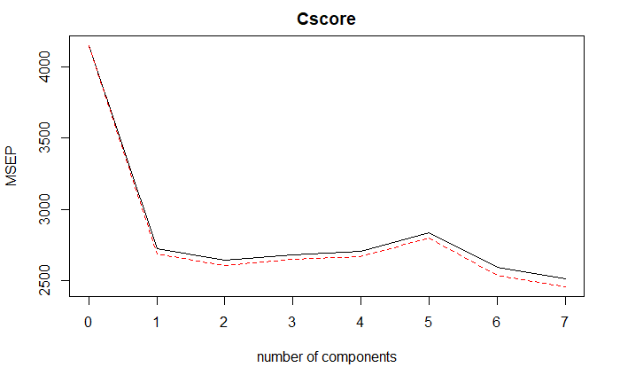

```r
pcr_model=pcr(Cscore~.,data=prostate,subset=train,scale=TRUE,
        validation="CV")
validationplot(pcr_model,val.type="MSEP")
```

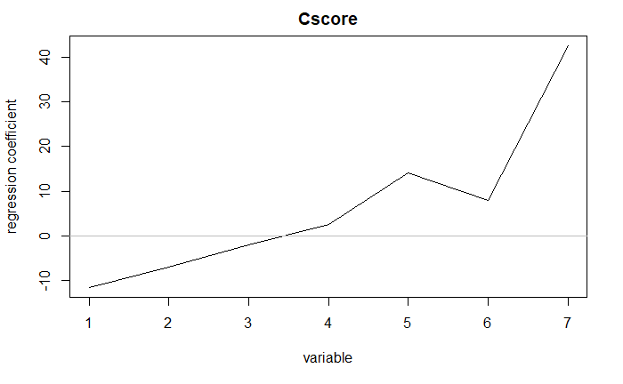

```r
coefplot(pcr_model)
```

```r
pcr_pred=predict(pcr_model,x[test,],ncomp=3)
pcr.mean = mean((pcr_pred-y.test)^2)
pcr_model=pcr(y~x,scale=TRUE,ncomp=3)
summary(pcr_model)
```

```
Data:   X dimension: 97 7
    Y dimension: 97 1
Fit method: svdpc
Number of components considered: 3
TRAINING: % variance explained
   1 comps  2 comps  3 comps
X    43.44    66.95    77.62
y    44.91    46.93    47.77
```

```r
pcr.mean
```

```
[1] 873
```

```r
OLS.mean
```

```
[1] 736
```

## How appropriate is PCR for this dataset?

When we look at the analysis we did, we can certainly say that there is some benefit to use PCR for this dataset, since we can explain a lot of the variance with only 3 principal components. However, when we use cross-validation for our 3-PC model, we can see that the test error of the PCR model is higher than the mean squared error of a normal linear regression model (see above). So, we do not think that PCR is really beneficial here.

# Model Comparison

## How well do they perform in general?

In general, the models perform quite good, but not super.

## Do they yield similar models?

Yes, for the most part, the same variables get included. However, the coefficients differ from model to model. PCR is the only outlier, since there is no variable selection going on.

## Which model do you think is the most appropriate for this dataset?

We selected the best model based on the test error. For this to make sense, we needed to remake the forward stepwise model with only the training data first.

```r
forward_training = forward_stepwise(prostate[train,])
forward_pred = predict(forward_training, newdata = prostate[test,], type = "response")
forward.mean = mean((forward_pred-y.test)^2)
OLS.mean
```

```
[1] 736
```

```r
forward.mean
```

```
[1] 803
```

```r
lasso.mean
```

```
[1] 664
```

```r
ridge.mean
```

```
[1] 675
```

```r
pcr.mean
```

```
[1] 873
```

The shown values are the test errors for a normal OLS model, forward stepwise prediction, lasso, ridge and PCR respectively. As we can see, only the lasso and ridge test error are under the OLS test error, and lasso is still slightly lower than ridge. This leads us to conclude that our lasso model is the most appropriate model for this dataset.